# team

Matthew Eisner and Cody Nielsen

9/8/2020

```r
choco <- read.csv("https://raw.githubusercontent.com/xdaiISU/ds202materials/master/hwlabs/data/choco.csv")
str(choco)
```

```
## 'data.frame':    2312 obs. of  13 variables:
##  $ REF                 : int  2454 2458 2454 797 797 1015 1019 1011 1019 1011 ...
##  $ Company             : Factor w/ 541 levels "5150","A. Morin",..: 1 1 1 2 2 2 2 2 2 2 ...
##  $ Location            : Factor w/ 67 levels "Amsterdam","Argentina",..: 63 63 63 19 19 19 19 19 19 19 ...
##  $ Date                : int  2019 2019 2019 2012 2012 2013 2013 2013 2013 2013 ...
##  $ Bean_Origin         : Factor w/ 63 levels "Australia","Belize",..: 30 14 54 38 5 62 38 16 38 7 ...
##  $ Specific_Bean_Origin: Factor w/ 1436 levels "\"heirloom\", Arriba Nacional",..: 141 1435 666 1029 179 289 267 482 267 189 ...
##  $ Cocoa_Percent       : num  76 76 76 63 70 70 63 70 70 70 ...
##  $ Ingredients         : Factor w/ 21 levels "1- B","2- B,C",..: 7 7 7 14 14 14 7 14 14 14 ...
##  $ Characteristics1    : Factor w/ 450 levels "accesible","accessible",..: 81 81 311 131 430 272 403 328 81 240 ...
##  $ Characteristics2    : Factor w/ 502 levels "","\"Andes\" mint",..: 29 482 137 236 304 301 94 304 408 NA ...
##  $ Characteristics3    : Factor w/ 341 levels "","accessible",..: 115 260 29 251 NA 48 306 66 148 NA ...
##  $ Characteristics4    : Factor w/ 88 levels "acidic","apple",..: NA NA NA NA NA 66 NA 29 NA NA ...
##  $ Rating              : num  3.75 3.5 3.25 3.75 3.5 4 4 3.75 3.5 3.25 ...
```

1. How are the ratings distributed? Create both a histogram and a boxplot and describe them. Don’t forget to mention outliers, if there are any.

According to the histogram, the ratings follow a distribution that is close in shape to a normal distribution. As shown in the boxplot, half of all ratings also fall between the 3.0 and 3.5 rating mark. The boxplot also reveals some outliers with ratings of 2.0, 1.75, 1.5, and 1.0.

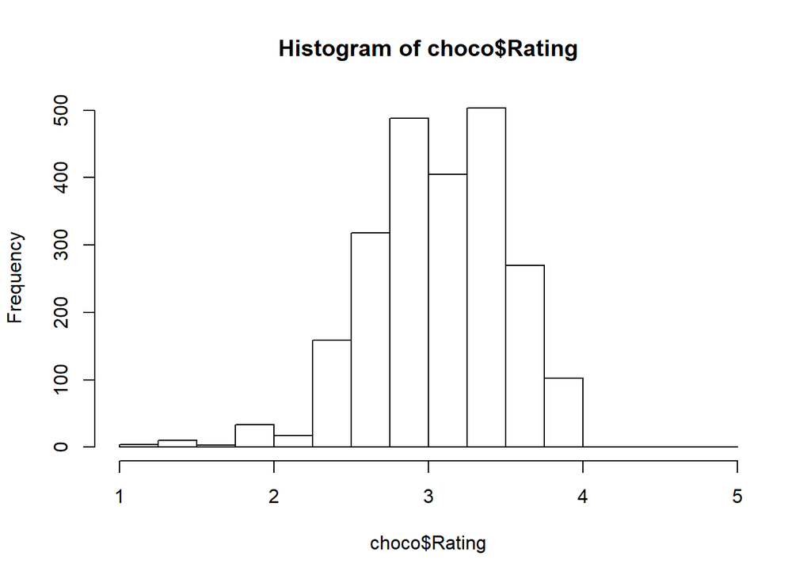

```r
hist(choco$Rating, breaks=seq(1,5,.25))
```

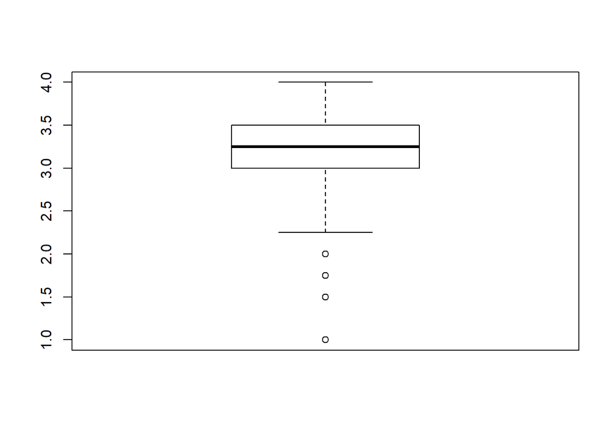

```r
boxplot(choco$Rating)
```

2. How does the number of ratings depend on the year? Draw a bar chart of the number of reports.

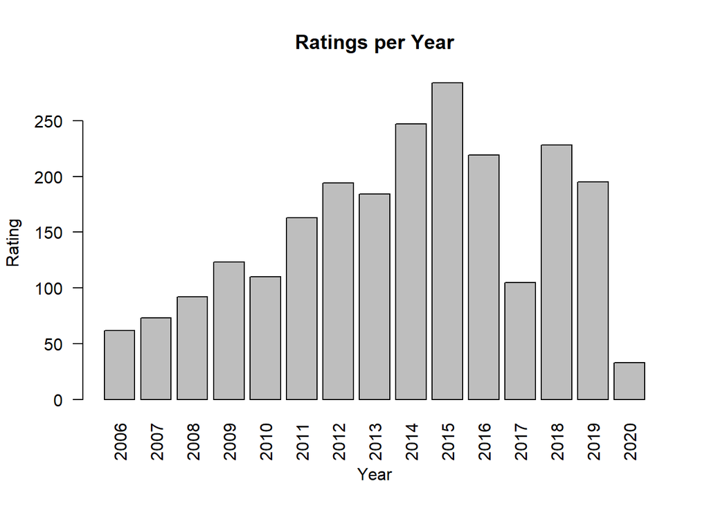

```r
year <- table(choco$Date)
barplot(year, las=2, main="Ratings per Year",xlab="Year",ylab="Rating")
```

3. Do ratings depend on the cacao percentage of a chocolate bar? Create both numerical and graphical summaries, and explain.

It does not appear that cacao percentage has a significant effect on the rating of the chocolate. This is because there is no obvious pattern in the scatterplot below, meaning there is no strong trend between the data sets. In addition, the correlation matrix shows that the correlation coefficient between the two values is only -0.151, which indicates that there is not a strong correlation between the variables as it is close to zero.

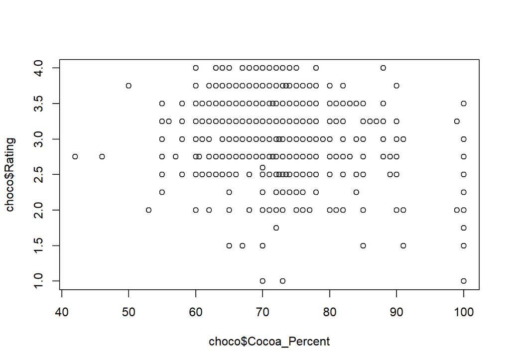

```r
plot(choco$Rating ~ choco$Cocoa_Percent)
```

```r
x <- choco[,c('Rating', 'Cocoa_Percent')]
cor(x)
```

```
##                   Rating Cocoa_Percent
## Rating         1.0000000    -0.1510178
## Cocoa_Percent -0.1510178     1.0000000
```

4. How do different characteristics of the chocolate compare? To elaborate, which characteristics tend to be more favorable and which ones are not? Create both numerical and graphical summaries, and explain.

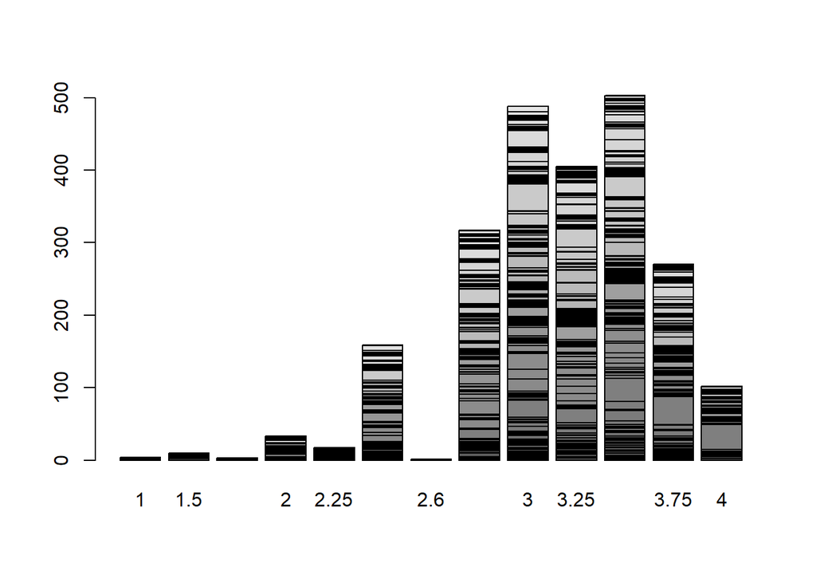

```r
char1 <- table(choco$Characteristics1,choco$Rating)
barplot(char1)
```

```r
head(char1, 15)
```

```
##
##                   1 1.5 1.75 2 2.25 2.5 2.6 2.75 3 3.25 3.5 3.75 4
##   accesible       0   0    0 0    0   0   0    0 0    0   1    0 0
##   accessible      0   0    0 0    0   0   0    0 1    0   0    0 0
##   acidic          0   2    0 0    0   1   0    1 1    3   1    0 0
##   alluring aroma  0   0    0 0    0   0   0    0 0    0   1    0 0
##   aluminum        0   0    0 0    0   0   0    0 1    0   0    0 0
##   anise           0   0    0 0    0   0   0    0 1    0   0    0 0
##   appealing smoke 0   0    0 0    0   0   0    0 0    0   0    1 0
##   apple           0   0    0 0    0   0   0    0 0    0   0    1 0
##   ashey           0   0    0 0    0   0   0    1 0    0   0    0 0
##   assertive       0   0    0 0    0   0   0    0 0    0   1    0 0
##   astringent      0   0    0 0    0   0   0    1 1    1   1    1 0
##   baked           0   0    0 0    0   0   0    0 1    0   0    0 0
##   baked bread     0   0    0 0    0   0   0    0 0    0   1    0 0
##   balanced        0   0    0 0    0   0   0    0 0    0   4    1 2
##   banana          0   0    0 0    0   1   0    0 2    1   2    1 3
```

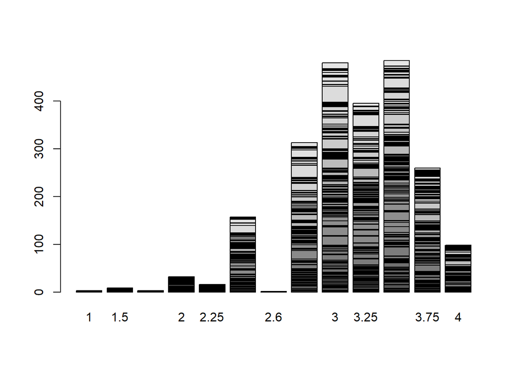

```r
char2 <- table(choco$Characteristics2,choco$Rating)
barplot(char2)
```

```r
head(char2, 15)
```

```
##
##                   1 1.5 1.75 2 2.25 2.5 2.6 2.75 3 3.25 3.5 3.75 4
##                   0   0    0 0    0   0   0    0 1    0   0    0 0
##   "Andes" mint    0   0    0 0    0   0   0    0 0    1   0    0 0
##   accessible      0   0    0 0    0   0   0    0 0    0   1    0 0
##   acidic          0   0    0 0    0   0   0    2 2    1   1    0 1
##   alkalyzed notes 0   0    0 0    0   0   0    1 0    0   0    0 0
##   almond          0   0    0 0    0   0   0    0 0    1   0    1 0
##   almond butter   0   0    0 0    0   0   0    0 0    0   1    0 0
##   almost burnt    0   0    0 0    0   1   0    0 0    0   0    0 0
##   alocohol        0   0    0 0    0   0   0    0 0    1   0    0 0
##   ambiguous       0   0    0 0    0   1   0    0 0    0   0    0 0
##   anise           0   0    0 0    0   0   0    0 0    1   1    1 0
##   artificial      0   0    0 0    0   1   0    0 0    0   0    0 0
##   ashey           0   0    0 0    0   2   0    1 1    1   0    0 0
##   astringent      0   1    0 1    0   0   0    2 5    0   2    2 0
##   balanced        0   0    0 0    0   0   0    0 0    0   2    2 1
```

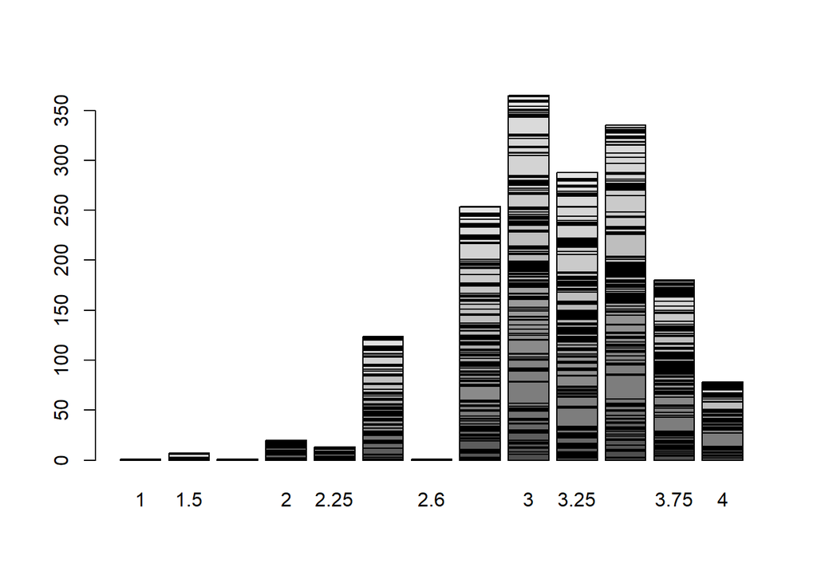

```r
char3 <- table(choco$Characteristics3,choco$Rating)
barplot(char3)
```

```r
head(char3, 15)
```

```
##
##                1 1.5 1.75 2 2.25 2.5 2.6 2.75 3 3.25 3.5 3.75 4
##                0   0    0 0    0   0   0    0 0    0   2    0 0
##   accessible   0   0    0 0    0   0   0    0 0    0   1    0 0
##   acidic       0   0    0 0    0   1   0    1 6    2   6    4 0
##   alcohol      0   0    0 0    0   0   0    0 0    0   1    0 0
##   anise        0   0    0 0    0   0   0    0 0    0   1    0 0
##   artificial   0   0    0 0    0   0   0    1 0    1   0    0 0
##   ashey        0   0    0 1    0   2   0    1 2    0   0    0 0
##   astingent    0   0    0 0    0   0   0    0 0    1   0    0 0
##   astringent   0   0    0 1    0   0   0    4 4    1   4    1 0
##   atypical     0   0    0 0    0   0   0    1 1    0   0    0 0
##   balanced     0   0    0 0    0   0   0    0 0    0   0    2 2
##   banana       0   0    0 0    0   2   0    0 3    0   5    2 2
##   banana cream 0   0    0 0    0   0   0    1 0    0   0    0 0
##   basic        0   0    0 0    0   0   0    0 0    1   1    0 0
##   basic cocoa  0   0    0 0    0   1   0    1 1    1   0    0 0
```

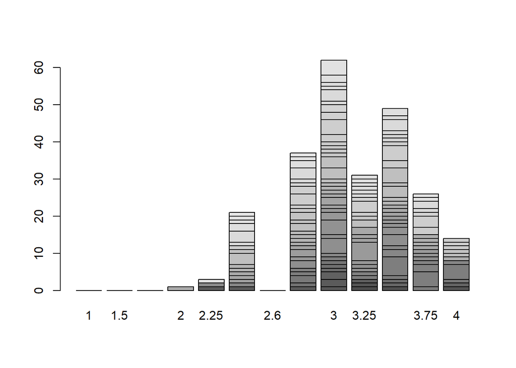

```r
char4 <- table(choco$Characteristics4,choco$Rating)
barplot(char4)
```

```r
head(char4, 15)
```

```
##
##              1 1.5 1.75 2 2.25 2.5 2.6 2.75 3 3.25 3.5 3.75 4
##   acidic     0   0    0 0    0   0   0    0 0    1   0    0 0
##   apple      0   0    0 0    0   0   0    0 0    0   1    0 0
##   banana     0   0    0 0    0   0   0    0 0    1   0    0 1
##   berry      0   0    0 0    0   0   0    0 1    0   0    0 0
##   bitter     0   0    0 0    1   1   0    1 2    0   0    0 0
##   blackberry 0   0    0 0    0   0   0    0 0    1   0    0 0
##   bland      0   0    0 0    0   0   0    0 2    0   0    0 0
##   bread      0   0    0 0    0   0   0    0 0    0   0    0 1
##   brownie    0   0    0 0    0   0   0    0 0    0   1    0 0
##   burning    0   0    0 0    0   0   0    0 1    0   0    0 0
##   candy      0   0    0 0    0   0   0    0 0    0   1    0 0
##   caramel    0   0    0 0    0   0   0    0 1    0   0    0 0
##   cardboard  0   0    0 0    0   0   0    1 0    0   0    0 0
##   chalky     0   0    0 0    0   0   0    0 1    0   0    0 0
##   cheese     0   0    0 0    0   0   0    0 0    0   0    0 1
```

It seems that the first characteristic has more of an effect on the rating than the following characteristics.

5. Brainstorm two analyses you would like to perform with your teammate. Describe in plain language what comparisons are you making. Create suitable numerical and graphical summaries for your analyses. Describe the results.

My (Matt Eisner) analysis will compare the percentage of cocoa used in chocolate between different countries. I have chosen 4 of the countries with the most amount of reviews: the United States, France, Canada, and the United Kingdom. I chose to utilizes histograms to visualize the data graphically. From the histograms, we see that the highest frequency of cocoa percent of the US and Canada was within the 65 to 70 percent range. For France and the UK, the highest frequency of cocoa percent fell within the 70 to 75 percent range. The mean, median and standard deviation of cocoa percent was also calculated for these countries and is shown in the dataframe below. From this summary, it was found that on average, the US uses the least amount of cocoa with a value of 71.6%. The UK has the highest mean cocoa percentage at 73.8%. In addition, the US data varied the least with a standard deviation of 4.9 and the UK data varied the most with a standard deviation of 7.4. The mean and median values for each country were also plotted on their respective histograms.

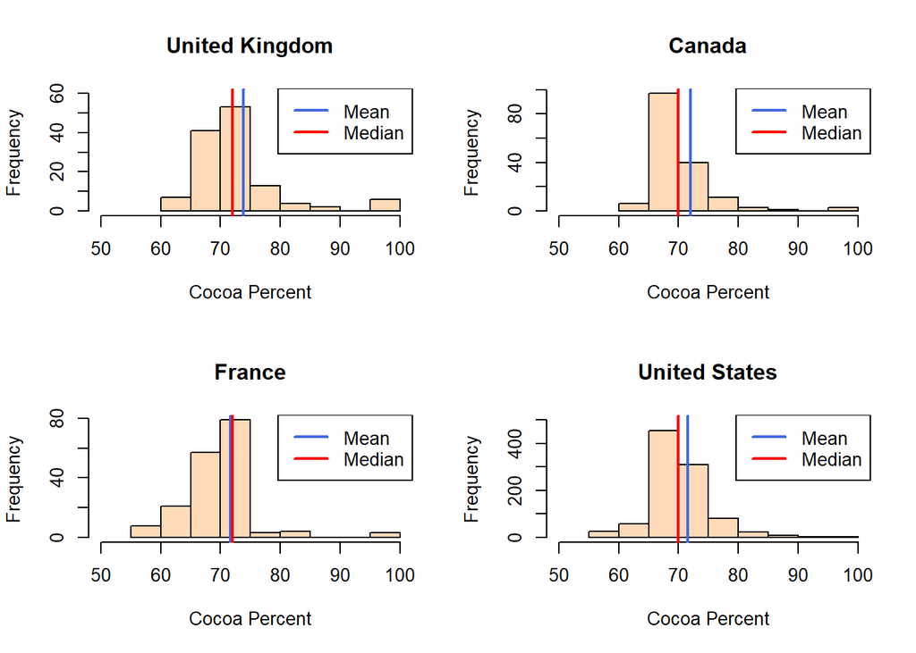

```r
library(ggplot2)

par(mfrow=c(2,2))

UK <- choco$Cocoa_Percent[choco$Location == 'U.K.']
CA <- choco$Cocoa_Percent[choco$Location == 'Canada']
FR <- choco$Cocoa_Percent[choco$Location == 'France']
USA <- choco$Cocoa_Percent[choco$Location == 'U.S.A.']

hist(UK, xlab='Cocoa Percent', main='United Kingdom', col='peachpuff', ylim=c(0,60), xlim=c(50,100))
abline(v = mean(UK), col = "royalblue", lwd = 2)
abline(v = median(UK), col = "red", lwd = 2)
legend(x = "topright", c("Mean", "Median"), col = c("royalblue", "red"), lwd = c(2, 2))

hist(CA, xlab='Cocoa Percent', main='Canada', col='peachpuff', xlim=c(50,100))
abline(v = mean(CA), col = "royalblue", lwd = 2)
abline(v = median(CA), col = "red", lwd = 2)
legend(x = "topright", c("Mean", "Median"), col = c("royalblue", "red"), lwd = c(2, 2))

hist(FR, xlab='Cocoa Percent', main='France', col='peachpuff', xlim=c(50,100))
abline(v = mean(FR), col = "royalblue", lwd = 2)
abline(v = median(FR), col = "red", lwd = 2)
legend(x = "topright", c("Mean", "Median"), col = c("royalblue", "red"), lwd = c(2, 2))

hist(USA, xlab='Cocoa Percent', main='United States', col='peachpuff', xlim=c(50,100), ylim=c(0,500))
abline(v = mean(USA), col = "royalblue", lwd = 2)
abline(v = median(USA), col = "red", lwd = 2)
legend(x = "topright", c("Mean", "Median"), col = c("royalblue", "red"), lwd = c(2, 2))
```

```r
country <- c('United Kingdom', 'Canada', 'France', 'United States')
mean <- c(mean(UK), mean(CA), mean(FR), mean(USA))
median <- c(median(UK), median(CA), median(FR), median(USA))
standard_deviation <- c(sd(UK), sd(CA), sd(FR), sd(USA))
country_data <- data.frame(country, mean, median, standard_deviation)
head(country_data)
```

```
##          country     mean median standard_deviation
## 1 United Kingdom 73.83730     72           7.417231
## 2         Canada 72.04969     70           5.423100
## 3         France 71.60571     72           6.418272
## 4  United States 71.59161     70           4.946569
```

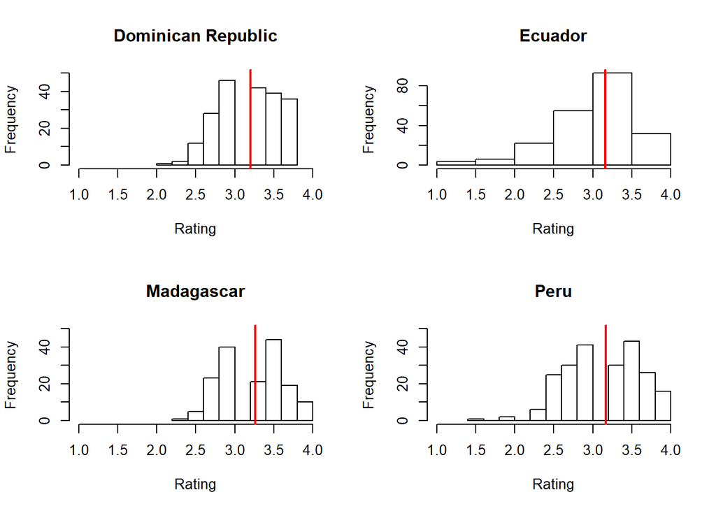

```r
library(ggplot2)

par(mfrow=c(2,2))

DR <- choco$Rating[choco$Bean_Origin == 'Dominican Republic']
Ecu <- choco$Rating[choco$Bean_Origin == 'Ecuador']
MAD <- choco$Rating[choco$Bean_Origin == 'Madagascar']
Per <- choco$Rating[choco$Bean_Origin == 'Peru']
Ven <- choco$Rating[choco$Bean_Origin == 'Venezuela']

hist(DR, main="Dominican Republic", xlab="Rating", xlim=c(1,4), ylim=c(0,50))
abline(v=mean(DR), col="red", lwd=2)
hist(Ecu, main="Ecuador", xlab="Rating", xlim=c(1,4))
abline(v=mean(Ecu), col="red", lwd=2)
hist(MAD, main="Madagascar", xlab="Rating", xlim=c(1,4), ylim=c(0,50))
abline(v=mean(MAD), col="red", lwd=2)
hist(Per, main="Peru", xlab="Rating", xlim=c(1,4), ylim=c(0,50))
abline(v=mean(Per), col="red", lwd=2)
```

[output not shown]

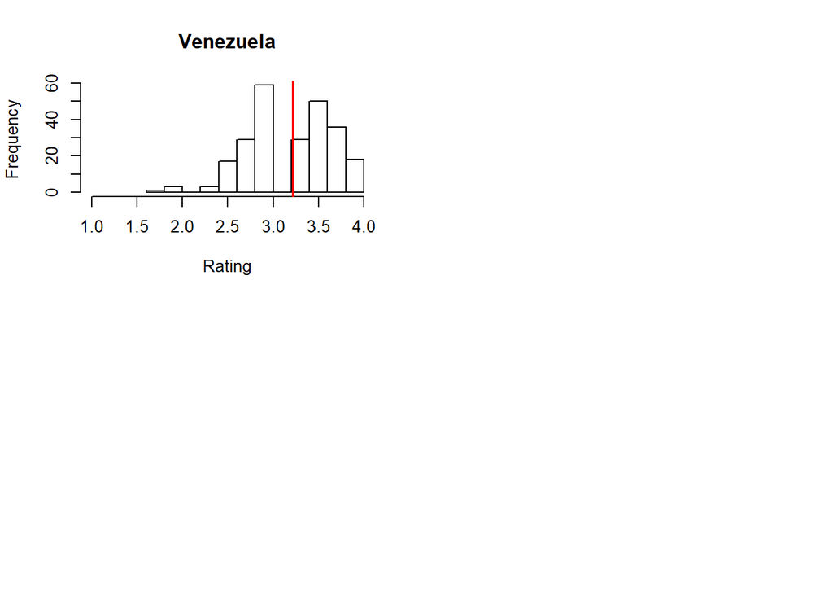

```r
hist(Ven, main="Venezuela", xlab="Rating", xlim=c(1,4))
abline(v=mean(Ven), col="red", lwd=2)
country <- c('Dominican Republic', 'Ecuador', 'Madagascar', 'Peru', 'Venezuela')
mean <- c(mean(DR), mean(Ecu), mean(MAD), mean(Per), mean(Ven))
stdn <- c(sd(DR), sd(Ecu), sd(MAD), sd(Per), sd(Ven))
range <- c(range(DR), range(Ecu), range(MAD), range(Per), range(Ven))
data <- data.frame(country, mean, stdn, range)
head(data, 5)
```

[output not shown]